# GESIS Spring Seminar 23

Comparative Social Research with Multi-Group SEM

Daniel Seddig, Eldad Davidov, Peter Schmidt, Yannick Diehl

Day 3 - 01.03.2023

# Packages

```r
# basic tools
library(tidyverse)

# building the models
library(lavaan)
library(sirt)
```

# Data

```r
ESS07 <- read.csv("../data/ESS07.csv")
```

# Alignment Method

## Approximate rather than exact MI?

MGCFA prodecures for testing MI are often impractical / very restrictive

- All non-target factor loadings in multifactor models are constrained to zero across groups
- Zero error covariances among the indicator variables across groups
- CFA model parameters (i.e., factor loadings, intercepts) are exactly equivalent across groups (“exact” approach; e.g., Zercher et al. (2015))

**MGCFA procedures for testing MI across a large number of groups often results in:**

Problems establishing a group-appropriate structure of the configural model

- numerous one-by-one comparisons
- time consuming
- error prone

Poor model fit of the scalar MI model

- large sample sizes
- small deviations across many groups may amount to misfit

Many large modification indexes

- numerous manual model adjustments
- time consuming
- error prone

## Why alignment?

**Goals**

- Compare latent variables across groups without constraints for measurement invariance
- Estimate factor means via MGCFA, but…
  - …without using equality constraints for factor loadings and intercepts across groups
  - …without affecting the comparability of factor means
  - …allowing for approximate measurement invariance
- Allows latent mean comparisons under approximate invariance
- Automates and greatly simplifies tests for invariance across a large number of groups (even as large as 92 groups; see Munck, Barber, and Torney-Purta (2018))

**Mathematical basis**

Incorporate a statistical criterion that is able to keep the degree of noninvariance at a minimum

Simplicity function F (total loss function) $F = \Sigma_p\Sigma_{gm<gn}W_{gm,gn}f(\lambda_{pgm}-\lambda_{pgn}) + \Sigma_p\Sigma_{gm<gn}W_{gm,gn}f(\tau_{pgm}-\tau_{pgn})$

weight factor, e.g. $W_{g1,g2}=\sqrt{N_{g1}N_{g2}}$

component loss function, e.g. $f(x)=\sqrt{\sqrt{x^2+0.01}}$ => generalized loss function Robitzsch (2020)

Generalized loss function: $f(x)=(x^2+\epsilon)^{p/2}$

- p: power
  - defines the shape of the loss function
  - lower values (e.g., p = 0.1 or p = 0.5): few large non-invariant parameters and many approximately invariant parameters (Mplus uses p = 0.5)
  - higher values (e.g., p = 2): all parameter deviations equally contribute to the aligned means and variances
- $\epsilon$: necessary for estimation
  - select a small value $\epsilon>0$
  - e.g. $\epsilon=0.01$ or $\epsilon=0.001$

## Procedure

### Step 1

Establish a configural model (i.e., the best fitting model)

- No cross-group constraints on factor loadings and intercepts
- Factor means and factor variances are fixed at 0.00 and 1.00, respectively

Measurement parameters are aligned to obtain a minimal degree of noninvariance without the requirement of equality constraints

- Many small parameter differences
- Few large parameter differences

### Step 2

Factor means and variances are freely estimated accounting for noninvariance with the ultimate aim to choose values of the factor means and factor variances that minimize the total loss in F (i.e., minimize the total amount of noninvariance)

Optimally F is minimized at a solution with

- A small number of large noninvariant measurement parameters
- A majority of approximately invariant measurement parameters

Aligned model still is the best fitting model

Analogy to exploratory factor analysis and factor rotation

- Rotation criteria aim at obtaining as many as possible small factor loadings and only a few large factor loadings

### Step 3

Post-estimation

- Identify measurement parameters that are approximately invariant and those that are not
- identify for each measurement parameter the largest invariant set of groups
- Multiple pairwise comparisons across groups based on p < .05
- Additional tests can identify measurement parameters that are approximately invariant and those that are not
  - $R^2_{intercept}=1-V(v_0-v-\alpha_g\lambda)/V(v_0)$
  - $R^2_{loading}=1-V(\lambda_0-\sqrt{\psi_g}\lambda)/V(\lambda_0)$
  - $rbar:$ average correlation of aligned item parameters among groups

**How much noninvariance is acceptable?**

Proportion of noninvariant parameters in the final alignment model

- < 25% - MuthÃ©n and Asparouhov (2014)
- < 29% - Flake and McCoach (2018)

Monte-Carlo simulations: high correlation of generated and estimated factor means (r ≥ 0.98)

## Alignment - Universalism

To calculate the alignment method, we first have to calculate the desired measurement model using lavaan.

```r
universalism_fit <- cfa(
  model = "
    group: [CZ]
    uni =~ NA*ipeqopt + ipudrst + impenv
    uni ~~ 1*uni
    uni ~ 0*1
    group: [DE]
    uni =~ NA*ipeqopt + ipudrst + impenv
    uni ~~ 1*uni
    uni ~ 0*1
    group: [GB]
    uni =~ NA*ipeqopt + ipudrst + impenv
    uni ~~ 1*uni
    uni ~ 0*1
  ",
  data = ESS07,
  estimator = "MLR",
  group = "country",
  # optional if there are missing values
  missing = "fiml.x"
)
```

For identification: factor variances are fixed to 1 and the factor means are fixed to zero (fixed factor method)

Second, extract parameter estimates for alignment:

```r
# Extract item parameters
ipars <- parameterEstimates(universalism_fit)

# Extract factor loadings (lambda's) (groups are in rows, items in columns)
l <- ipars %>%
  # Filter for factor loadings
  filter(op == "=~") %>%
  # Select column with unstd. loadings
  select(est) %>%
  # get vector
  flatten_dbl() %>%
  # transform to matrix
  matrix(nrow = 3, byrow = T)

# Extract interepts (nu's)
n <- ipars %>%
  # Filter for intercepts with standard error is not 0
  filter(op == "~1" & se != 0) %>%
  # Select column with intercepts
  select(est) %>%
  # transform to vector
  flatten_dbl() %>%
  # transform to matrix
  matrix(nrow = 3, byrow = T)
```

Third, alignment with sirt:

invariance.alignment(): performs alignment under approximate invariance for a CFA with G groups and I items

- Estimate loadings and intercepts as a unidimensional factor model with factor mean and variance fixed to zero and one, resp.
- Extract item parameters and estimates

```r
# Invariance alignment with default power (0.5) and epsilon (0.001)
uni_align1 <- invariance.alignment(lambda=l,nu=n)

summary(uni_align1)
```

```
-----------------------------------------------------------------
sirt 3.12-66 (2022-05-16 12:27:54)
R version 4.2.2 (2022-10-31) x86_64, darwin17.0 | nodename=Yannicks-MacBook-Pro.local | login=root

Call:
invariance.alignment(lambda = l, nu = n)

Date of Analysis: 2023-03-02 00:44:46
Time difference of 0.01061416 secs
Computation Time: 0.01061416

-----------------------------------------------------------------
Optimization Function Value = 1.227
Optimizer = optim
Fixed = TRUE
Converged = TRUE
Alignment Power Values = 0.5 0.5
Alignment Scale Values = 1 1
Epsilon Value = 0.001
Optimization method meth = 1
-----------------------------------------------------------------
Number of items per group
G1 G2 G3
 3  3  3
-----------------------------------------------------------------
Effect Sizes of Approximate Invariance
       loadings intercepts
R2        0.987      1.000
sqrtU2    0.115      0.014
rbar     -0.374      0.779
-----------------------------------------------------------------
Group Means and Standard Deviations (center=FALSE)
   alpha0  psi0
G1  0.000 1.000
G2  0.881 0.814
G3  0.642 0.938
-----------------------------------------------------------------
Summary Aligned Item Parameters Lambda
   Med.lambda M.lambda SD.lambda Min.lambda Max.lambda
I1      0.602    0.601     0.003      0.597      0.603
```

[output cut: 13 more lines]

```
G3 0.597 0.754 0.457
-----------------------------------------------------------------
Aligned Nu Parameters
      I1    I2    I3
G1 4.538 4.252 4.688
G2 4.595 4.448 4.509
G3 4.610 4.232 4.555
-----------------------------------------------------------------
Summary Absolute Residuals Loadings Lambda
   Min. 1st Qu.  Median    Mean 3rd Qu.    Max.
  0.001   0.002   0.054   0.049   0.098   0.118
-----------------------------------------------------------------
Summary Absolute Residuals Intercepts Nu
   Min. 1st Qu.  Median    Mean 3rd Qu.    Max.
  0.014   0.029   0.059   0.063   0.079   0.137
```

**Result**

- Under Effect Sizes of Approximate Invariance we can see that both the factor loadings and the intercepts are close to 1 (loadings R2: .987; intercepts: 1.00). The following applies: Values close to 1 imply a high degree of invariance. Values close to 0 imply a low degree of invariance. We thus have a strong indication of at least approximate invariance between the groups.
- Under Group Means and Standard Deviations we find the relative latent mean values to Group 1 (CZ), as well as the associated standard deviation. Accordingly, it turns out that DE and GB have a relatively higher latent mean than CZ.
- Under Summary Aligned Item Parameters Lambda / Nu we can see which parameters differ significantly between the groups. It can be seen that I2 (ipudrst) shows the greatest variance among SD.lambda and the factor loadings differ the most across the groups here. The same goes for the intercepts on this item. Here it can be seen under SD.nu that there is a clear variance between the groups. We can also understand this result using the absolute factor loadings and intercepts under Aligned Lambda / Nu Parameters.

**Find parameter constraints for a pre-specified level tolerance**

invariance_alignment_constraints(): postprocessing, estimation of item parameters under equality constraints for prespecified absolute values of “parameter tolerance”

- Tolerance: degree of noninvariance tolerated => possible for loading and intercept parameters

```r
invariance_alignment_constraints(
  model = uni_align1,
  lambda_parm_tol=.2,
  nu_parm_tol=.4
  ) %>%
  summary()
```

```
-----------------------------------------------------------------
sirt 3.12-66 (2022-05-16 12:27:54)
R version 4.2.2 (2022-10-31) x86_64, darwin17.0 | nodename=Yannicks-MacBook-Pro.local | login=root

Call:
invariance_alignment_constraints(model = uni_align1, lambda_parm_tol = 0.2,
    nu_parm_tol = 0.4)

Invariance Alignment with Post-Hoc Item Parameter Constraints

Optimization Function Value = 1.227
Optimizer = optim
Fixed = TRUE
Converged = TRUE
Alignment Power Values = 0.5 0.5
Alignment Scale Values = 1 1
Epsilon Value = 0.001
Optimization method meth = 1
-----------------------------------------------------------------
Alignment Results Lambda Parameters

Parameter tolerance value = 0.2
Total number of items = 9
Number of unique item parameters = 3
Percentage of noninvariance item parameters = 0 %

Unique item parameters per item
I1 I2 I3
 0  0  0

Unique item parameters per group
G1 G2 G3
 0  0  0

Joint item parameters
   I1    I2    I3
0.602 0.582 0.553

Estimated item parameters
      I1    I2    I3
```

[output cut: 25 more lines]

```
Joint item parameters
   I1    I2    I3
4.595 4.252 4.555

Estimated item parameters
      I1    I2    I3
G1 4.595 4.252 4.555
G2 4.595 4.252 4.555
G3 4.595 4.252 4.555

Estimated DIF effects
   I1 I2 I3
G1  0  0  0
G2  0  0  0
G3  0  0  0
```

**Result**

- With the tolerance values of .2 for factor loadings and .4 for intercepts, our measurement model has no other deviating parameters for factor loadings and intercepts within this approximation, i.e. 0% noninvariance item parameters. So we can at least assume an approximate scalar measurement invariance.

**Invariance alignment with higher power (2)**

```r
# Invariance alignment with higher power (2) and default epsilon (0.001)
uni_align2 <- invariance.alignment(lambda=l,nu=n,align.pow=c(2,2))

summary(uni_align2)
```

```
-----------------------------------------------------------------
sirt 3.12-66 (2022-05-16 12:27:54)
R version 4.2.2 (2022-10-31) x86_64, darwin17.0 | nodename=Yannicks-MacBook-Pro.local | login=root

Call:
invariance.alignment(lambda = l, nu = n, align.pow = c(2, 2))

Date of Analysis: 2023-03-02 00:44:47
Time difference of 0.005402088 secs
Computation Time: 0.005402088

-----------------------------------------------------------------
Optimization Function Value = 0.058
Optimizer = optim
Fixed = TRUE
Converged = TRUE
Alignment Power Values = 2 2
Alignment Scale Values = 1 1
Epsilon Value = 0.001
Optimization method meth = 1
-----------------------------------------------------------------
Number of items per group
G1 G2 G3
 3  3  3
-----------------------------------------------------------------
Effect Sizes of Approximate Invariance
       loadings intercepts
R2        0.987      1.000
sqrtU2    0.114      0.014
rbar     -0.374      0.784
-----------------------------------------------------------------
Group Means and Standard Deviations (center=FALSE)
   alpha0  psi0
G1  0.000 1.000
G2  0.901 0.795
G3  0.616 0.981
-----------------------------------------------------------------
Summary Aligned Item Parameters Lambda
   Med.lambda M.lambda SD.lambda Min.lambda Max.lambda
I1      0.603    0.597     0.024      0.571      0.617
```

[output cut: 13 more lines]

```
G3 0.571 0.721 0.437
-----------------------------------------------------------------
Aligned Nu Parameters
      I1    I2    I3
G1 4.538 4.252 4.688
G2 4.570 4.424 4.486
G3 4.642 4.272 4.580
-----------------------------------------------------------------
Summary Absolute Residuals Loadings Lambda
   Min. 1st Qu.  Median    Mean 3rd Qu.    Max.
  0.006   0.020   0.034   0.052   0.091   0.116
-----------------------------------------------------------------
Summary Absolute Residuals Intercepts Nu
   Min. 1st Qu.  Median    Mean 3rd Qu.    Max.
  0.005   0.044   0.059   0.060   0.099   0.108
```

## Summary

**Greatly simplifies MI testing and estimation of latent means for comparison across groups**

Useful in situations

- Where latent mean comparisons are desired
- With many groups
- With many approximately invariant parameters
- With a few large non-invariant parameter

# Multigroup SEM

## Why MGSEM?

After testing MI, we may be interested not only in comparing means or variances of latent variables across countries, but also comparing…

- … correlations between constructs
- … regression coefficients
- (… indirect and total effects, mediation)
- (… interaction)

Separate (full) structural models in two or more groups

- Separate estimates of within-group parameters (e.g., paths coefficients, correlations)
- Separate χ2 and fit indices for each group and global fit indices
- Compare multiple groups simultaneously or pairs of groups (e.g., parameter constraints across groups for setting predictive paths equal for all or some of the groups)

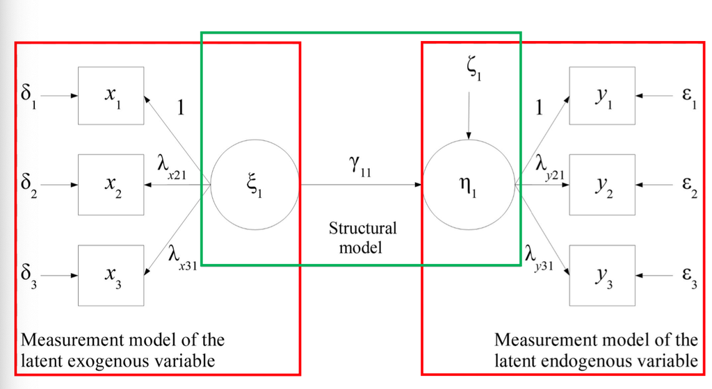

In case of two groups (g1 & g2) the structural equations are:

$$\begin{split}
\eta_{1,g1}=\xi_{1,g1}*\gamma_{11,g1}+\zeta_{1,g1} \\
\eta_{1,g2}=\xi_{1,g2}*\gamma_{11,g2}+\zeta_{1,g2} \\
\end{split}$$

Measurement parameters should be invariant across groups

- Factor loadings (metric MI), e.g. fpr slope comparisons
- Factor loadings and intercepts (scalar MI), e.g. for latent mean comparison

## Moderation

Among other things, MGSEM can be used to answer whether the regression coefficient differs between two groups, i.e. whether the group variable forms a moderation effect between the predictor and the dependent variable.

**Moderation**

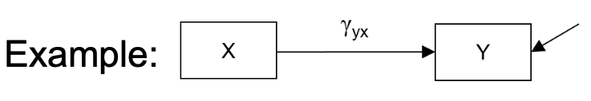

Differs $\gamma_{xy}$ for values of Z?

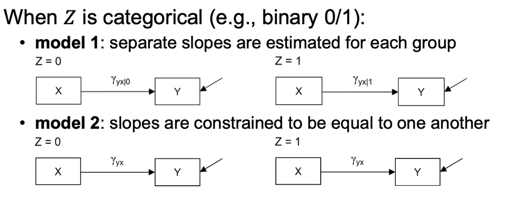

- One-df $\chi^2$-test: are the slope differences significant?
- Asymptotically equivalent to a regression in which Y is regressed on the product variable XZ

**Moderated mediation**

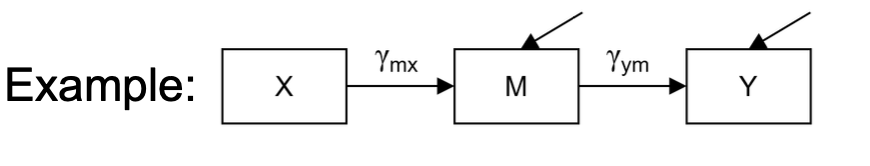

- M is the mediator
- Z is the moderator (grouping variable)

When Z is categorical (e.g., binary 0/1):

- Separate the model into groups
- Impose equality constraints on either X -> M or M -> Y path, or both
- $\chi^2$ comparison of constrained and unconstrained models

## MGSEM - Model

Compare the relationship between universalism and perceived threat across CZ, DE, and GB

Test for $\chi^2$ difference => both models have equal factor loadings (metric MI) across groups

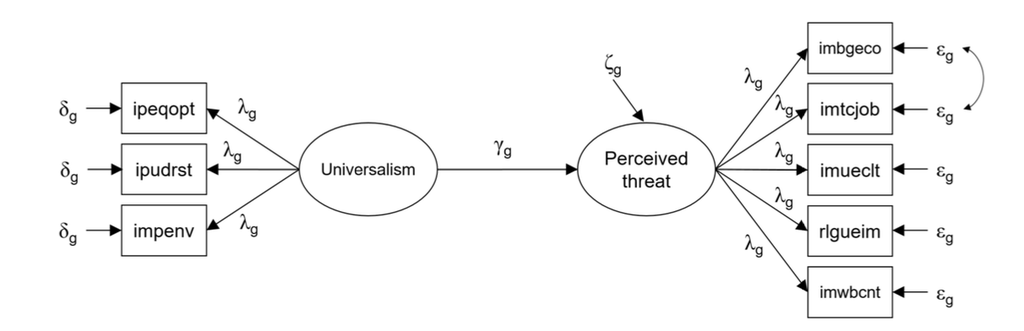

### Step 1

Next, we want to know if the model works across all countries, assuming metric measurement invariance. For this we first let the regression coefficients between the latent variables be freely calculated.

Model 1: Regression coefficent ($\gamma$) different across countries

```r
mgsem1_free <- cfa(
  model = "
    # measurement model
    uni =~ ipeqopt + ipudrst + impenv
    pthr =~ imbgeco + imtcjob + imueclt + rlgueim + imwbcnt
    imbgeco ~~ imtcjob

    # structural model
    pthr ~ uni
  ",
  data = ESS07,
  estimator = "MLR",
  group = "country",
  group.equal = c("loadings"),
  # optional if there are missing values
  missing = "fiml.x"
)
```

```r
summary(
  object = mgsem1_free,
  fit.measures = T,
  standardized = T,
  rsquare = T
)
```

```
lavaan 0.6.14 ended normally after 99 iterations

  Estimator                                         ML
  Optimization method                           NLMINB
  Number of model parameters                        78
  Number of equality constraints                    12

  Number of observations per group:
    CZ                                            1393
    DE                                            2671
    GB                                            1780
  Number of missing patterns per group:
    CZ                                               1
    DE                                               1
    GB                                               1

Model Test User Model:
                                              Standard      Scaled
  Test Statistic                               375.784     309.565
  Degrees of freedom                                66          66
  P-value (Chi-square)                           0.000       0.000
  Scaling correction factor                                  1.214
    Yuan-Bentler correction (Mplus variant)
  Test statistic for each group:
    CZ                                         101.114      83.296
    DE                                         142.470     117.365
    GB                                         132.200     108.905

Model Test Baseline Model:

  Test statistic                             14329.888   10325.696
  Degrees of freedom                                84          84
  P-value                                        0.000       0.000
  Scaling correction factor                                  1.388

User Model versus Baseline Model:

  Comparative Fit Index (CFI)                    0.978       0.976
  Tucker-Lewis Index (TLI)                       0.972       0.970

```

[output cut: 216 more lines]

```
   .imwbcnt           1.213    0.103   11.780    0.000    1.213    0.193
    uni               0.392    0.040    9.799    0.000    1.000    1.000
   .pthr              3.290    0.160   20.503    0.000    0.834    0.834

R-Square:
                   Estimate
    ipeqopt           0.357
    ipudrst           0.320
    impenv            0.198
    imbgeco           0.617
    imtcjob           0.373
    imueclt           0.774
    rlgueim           0.392
    imwbcnt           0.807
    pthr              0.166
```

The model shows a good data fit, we then check whether the regression coefficient between universalism and perceived threat is invariant.

### Step 2

Model 2: Regression coefficient ($\gamma$) equal across countries

```r
mgsem1_constraint <- cfa(
  model = "
    # measurement model
    uni =~ ipeqopt + ipudrst + impenv
    pthr =~ imbgeco + imtcjob + imueclt + rlgueim + imwbcnt
    imbgeco ~~ imtcjob

    # structural model
    pthr ~ uni
  ",
  data = ESS07,
  estimator = "MLR",
  group = "country",
  group.equal = c("loadings", "regressions"),
  # optional if there are missing values
  missing = "fiml.x"
)
```

```r
summary(
  object = mgsem1_constraint,
  fit.measures = T,
  standardized = T,
  rsquare = T
)
```

```
lavaan 0.6.14 ended normally after 94 iterations

  Estimator                                         ML
  Optimization method                           NLMINB
  Number of model parameters                        78
  Number of equality constraints                    14

  Number of observations per group:
    CZ                                            1393
    DE                                            2671
    GB                                            1780
  Number of missing patterns per group:
    CZ                                               1
    DE                                               1
    GB                                               1

Model Test User Model:
                                              Standard      Scaled
  Test Statistic                               490.182     406.168
  Degrees of freedom                                68          68
  P-value (Chi-square)                           0.000       0.000
  Scaling correction factor                                  1.207
    Yuan-Bentler correction (Mplus variant)
  Test statistic for each group:
    CZ                                         181.062     150.029
    DE                                         165.809     137.391
    GB                                         143.310     118.748

Model Test Baseline Model:

  Test statistic                             14329.888   10325.696
  Degrees of freedom                                84          84
  P-value                                        0.000       0.000
  Scaling correction factor                                  1.388

User Model versus Baseline Model:

  Comparative Fit Index (CFI)                    0.970       0.967
  Tucker-Lewis Index (TLI)                       0.963       0.959

```

[output cut: 216 more lines]

```
   .imwbcnt           1.209    0.103   11.711    0.000    1.209    0.198
    uni               0.404    0.041    9.875    0.000    1.000    1.000
   .pthr              3.458    0.157   22.088    0.000    0.907    0.907

R-Square:
                   Estimate
    ipeqopt           0.363
    ipudrst           0.348
    impenv            0.207
    imbgeco           0.609
    imtcjob           0.366
    imueclt           0.767
    rlgueim           0.383
    imwbcnt           0.802
    pthr              0.093
```

### Step 3

```r
lavTestLRT(mgsem1_free, mgsem1_constraint)
```

```
Scaled Chi-Squared Difference Test (method = "satorra.bentler.2001")

lavaan NOTE:
    The "Chisq" column contains standard test statistics, not the
    robust test that should be reported per model. A robust difference
    test is a function of two standard (not robust) statistics.

                  Df    AIC    BIC  Chisq Chisq diff Df diff Pr(>Chisq)
mgsem1_free       66 165893 166333 375.78
mgsem1_constraint 68 166003 166430 490.18     117.48       2  < 2.2e-16 ***
---
Signif. codes:  0 '***' 0.001 '**' 0.01 '*' 0.05 '.' 0.1 ' ' 1
```

**Result**

- The more restrictive model (i.e., the one with equal regression coefficients) fits worse
- In the MGSEM without constraints, we can clearly see under R-Square that the perseived threat in DE and GB can be explained proportionately by universalism. Only in CZ do we see practically no effect.

### Step 4

Consequently, in step 4 we want to try whether a model with free calculated regression coefficients in CZ and an equal coefficient between DE and GB is a better model.

```r
mgsem1_constraint_partial <- sem(
  model = "
    group: [CZ]
    uni =~ a*ipeqopt + b*ipudrst + c*impenv
    pthr =~ d*imbgeco + e*imtcjob + f*imueclt + g*rlgueim + h*imwbcnt
    imbgeco ~~ imtcjob
    pthr ~ uni

    group: [DE]
    uni =~ a*ipeqopt + b*ipudrst + c*impenv
    pthr =~ d*imbgeco + e*imtcjob + f*imueclt + g*rlgueim + h*imwbcnt
    imbgeco ~~ imtcjob
    pthr ~ i*uni

    group: [GB]
    uni =~ a*ipeqopt + b*ipudrst + c*impenv
    pthr =~ d*imbgeco + e*imtcjob + f*imueclt + g*rlgueim + h*imwbcnt
    imbgeco ~~ imtcjob
    pthr ~ i*uni
  ",
  data = ESS07,
  estimator = "MLR",
  group = "country",
  # optional if there are missing values
  missing = "fiml.x"
)
```

```r
summary(
  object = mgsem1_constraint_partial,
  fit.measures = T,
  standardized = T
  # rsquare = T
)
```

```
lavaan 0.6.14 ended normally after 88 iterations

  Estimator                                         ML
  Optimization method                           NLMINB
  Number of model parameters                        78
  Number of equality constraints                    13

  Number of observations per group:
    CZ                                            1393
    DE                                            2671
    GB                                            1780
  Number of missing patterns per group:
    CZ                                               1
    DE                                               1
    GB                                               1

Model Test User Model:
                                              Standard      Scaled
  Test Statistic                               376.149     309.878
  Degrees of freedom                                67          67
  P-value (Chi-square)                           0.000       0.000
  Scaling correction factor                                  1.214
    Yuan-Bentler correction (Mplus variant)
  Test statistic for each group:
    CZ                                         101.117      83.302
    DE                                         142.604     117.479
    GB                                         132.427     109.096

Model Test Baseline Model:

  Test statistic                             14329.888   10325.696
  Degrees of freedom                                84          84
  P-value                                        0.000       0.000
  Scaling correction factor                                  1.388

User Model versus Baseline Model:

  Comparative Fit Index (CFI)                    0.978       0.976
  Tucker-Lewis Index (TLI)                       0.973       0.970

```

[output cut: 180 more lines]

```
    uni               0.000                               0.000    0.000
   .pthr              0.000                               0.000    0.000

Variances:
                   Estimate  Std.Err  z-value  P(>|z|)   Std.lv  Std.all
   .ipeqopt           0.708    0.045   15.622    0.000    0.708    0.645
   .ipudrst           0.745    0.040   18.430    0.000    0.745    0.684
   .impenv            0.985    0.041   23.899    0.000    0.985    0.804
   .imbgeco           2.449    0.126   19.423    0.000    2.449    0.382
   .imtcjob           3.336    0.144   23.153    0.000    3.336    0.626
   .imueclt           1.611    0.116   13.933    0.000    1.611    0.225
   .rlgueim           3.208    0.150   21.335    0.000    3.208    0.607
   .imwbcnt           1.213    0.103   11.786    0.000    1.213    0.192
    uni               0.389    0.039    9.989    0.000    1.000    1.000
   .pthr              3.269    0.154   21.189    0.000    0.824    0.824
```

```r
lavTestLRT(mgsem1_free, mgsem1_constraint, mgsem1_constraint_partial)
```

```
Scaled Chi-Squared Difference Test (method = "satorra.bentler.2001")

lavaan NOTE:
    The "Chisq" column contains standard test statistics, not the
    robust test that should be reported per model. A robust difference
    test is a function of two standard (not robust) statistics.

                          Df    AIC    BIC  Chisq Chisq diff Df diff Pr(>Chisq)
mgsem1_free               66 165893 166333 375.78
mgsem1_constraint_partial 67 165891 166325 376.15      0.301       1     0.5832
mgsem1_constraint         68 166003 166430 490.18    154.760       1     <2e-16

mgsem1_free
mgsem1_constraint_partial
mgsem1_constraint         ***
---
Signif. codes:  0 '***' 0.001 '**' 0.01 '*' 0.05 '.' 0.1 ' ' 1
```

**Result**

- The effect of universalism on perceived threat is equal in DE and GB
- The effect of universalism on perceived threat in CZ is not equal to the same effect in DE and GB
- Universalism has no effect perceived threat in CZ
- Universalism has negative effects on perceived threat negatively in DE and GB
- The effects are equal in DE and GB

## MGSEM - Model 2

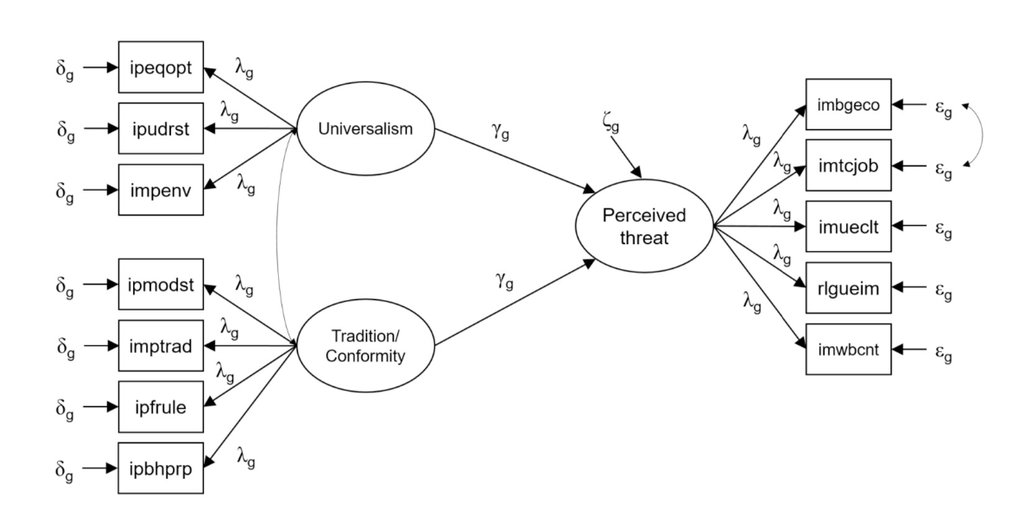

With this model, we explicitly want to draw on our knowledge from simultaneous factor analysis and use the partial scalar measurement invariance model as a basis.

### Step 1

Model 1: Correlation coefficent between universalism and tradition/conformity ($\phi_{12}$) different across countries

```r
mgsem2_free <- cfa(
  model = "
    # measurement model
    uni =~ ipeqopt + ipudrst + impenv
    traco =~ imptrad + ipfrule + ipbhprp
    pthr =~ imbgeco + imueclt + imtcjob + rlgueim
    imueclt ~~ rlgueim

    # structural model
    pthr ~ uni + traco
  ",
  data = ESS07,
  estimator = "MLR",
  group = "country",
  group.equal = c("loadings", "intercepts"),
  group.partial = c("ipbhprp~1", "impenv~1", "imbgeco~1"),
  # optional if there are missing values
  missing = "fiml.x"
)
```

```r
summary(
  object = mgsem2_free,
  fit.measures = T,
  standardized = T,
  rsquare = T
)
```

```
lavaan 0.6.14 ended normally after 183 iterations

  Estimator                                         ML
  Optimization method                           NLMINB
  Number of model parameters                       108
  Number of equality constraints                    28

  Number of observations per group:
    CZ                                            1393
    DE                                            2671
    GB                                            1780
  Number of missing patterns per group:
    CZ                                               1
    DE                                               1
    GB                                               1

Model Test User Model:
                                              Standard      Scaled
  Test Statistic                               707.291     608.850
  Degrees of freedom                               115         115
  P-value (Chi-square)                           0.000       0.000
  Scaling correction factor                                  1.162
    Yuan-Bentler correction (Mplus variant)
  Test statistic for each group:
    CZ                                         158.542     136.476
    DE                                         267.512     230.279
    GB                                         281.237     242.094

Model Test Baseline Model:

  Test statistic                             11661.448    9234.176
  Degrees of freedom                               135         135
  P-value                                        0.000       0.000
  Scaling correction factor                                  1.263

User Model versus Baseline Model:

  Comparative Fit Index (CFI)                    0.949       0.946
  Tucker-Lewis Index (TLI)                       0.940       0.936

```

[output cut: 258 more lines]

```
   .pthr              3.375    0.217   15.587    0.000    0.746    0.746

R-Square:
                   Estimate
    ipeqopt           0.285
    ipudrst           0.342
    impenv            0.235
    imptrad           0.201
    ipfrule           0.351
    ipbhprp           0.456
    imbgeco           0.722
    imueclt           0.592
    imtcjob           0.458
    rlgueim           0.271
    pthr              0.254
```

### Step 2

Model 2: Correlation coefficent between universalism and tradition/conformity ($\phi_{12}$) equal across countries

```r
mgsem2_constraint <- cfa(
  model = "
    # measurement model
    uni =~ ipeqopt + ipudrst + impenv
    traco =~ imptrad + ipfrule + ipbhprp
    pthr =~ imbgeco + imueclt + imtcjob + rlgueim
    imueclt ~~ rlgueim

    # structural model
    pthr ~ uni + traco

    # Correlation
    uni ~~ i*traco
  ",
  data = ESS07,
  estimator = "MLR",
  group = "country",
  group.equal = c("loadings", "intercepts"),
  group.partial = c("ipbhprp~1", "impenv~1", "imbgeco~1"),
  # optional if there are missing values
  missing = "fiml.x"
)
```

```r
summary(
  object = mgsem2_constraint,
  fit.measures = T,
  standardized = T,
  rsquare = T
)
```

```
lavaan 0.6.14 ended normally after 177 iterations

  Estimator                                         ML
  Optimization method                           NLMINB
  Number of model parameters                       108
  Number of equality constraints                    30

  Number of observations per group:
    CZ                                            1393
    DE                                            2671
    GB                                            1780
  Number of missing patterns per group:
    CZ                                               1
    DE                                               1
    GB                                               1

Model Test User Model:
                                              Standard      Scaled
  Test Statistic                               865.382     743.607
  Degrees of freedom                               117         117
  P-value (Chi-square)                           0.000       0.000
  Scaling correction factor                                  1.164
    Yuan-Bentler correction (Mplus variant)
  Test statistic for each group:
    CZ                                         256.075     220.040
    DE                                         319.095     274.192
    GB                                         290.213     249.374

Model Test Baseline Model:

  Test statistic                             11661.448    9234.176
  Degrees of freedom                               135         135
  P-value                                        0.000       0.000
  Scaling correction factor                                  1.263

User Model versus Baseline Model:

  Comparative Fit Index (CFI)                    0.935       0.931
  Tucker-Lewis Index (TLI)                       0.925       0.921

```

[output cut: 258 more lines]

```
   .pthr              3.349    0.219   15.262    0.000    0.744    0.744

R-Square:
                   Estimate
    ipeqopt           0.287
    ipudrst           0.349
    impenv            0.252
    imptrad           0.210
    ipfrule           0.366
    ipbhprp           0.459
    imbgeco           0.721
    imueclt           0.590
    imtcjob           0.457
    rlgueim           0.270
    pthr              0.256
```

### Step 4

```r
lavTestLRT(mgsem2_free, mgsem2_constraint)
```

```
Scaled Chi-Squared Difference Test (method = "satorra.bentler.2001")

lavaan NOTE:
    The "Chisq" column contains standard test statistics, not the
    robust test that should be reported per model. A robust difference
    test is a function of two standard (not robust) statistics.

                   Df    AIC    BIC  Chisq Chisq diff Df diff Pr(>Chisq)
mgsem2_free       115 202363 202896 707.29
mgsem2_constraint 117 202517 203037 865.38      123.2       2  < 2.2e-16 ***
---
Signif. codes:  0 '***' 0.001 '**' 0.01 '*' 0.05 '.' 0.1 ' ' 1
```

### Step 4

```r
mgsem2_constraint_partial <- cfa(
  model = "
    group: [CZ]

      # measurement model
      uni =~ a*ipeqopt + b*ipudrst + c*impenv
      ipeqopt ~ k*1
      ipudrst ~ l*1
      impenv ~ NA*1
      uni ~ 0*1

      traco =~ d*imptrad + e*ipfrule + f*ipbhprp
      imptrad ~ o*1
      ipfrule ~ p*1
      ipbhprp ~ NA*1
      traco ~ 0*1

      pthr =~ g*imbgeco + h*imueclt + i*imtcjob + j*rlgueim
      imueclt ~~ rlgueim
      imbgeco ~ NA*1
      imueclt ~ s*1
      imtcjob ~ t*1
      rlgueim ~ u*1
      pthr ~ 0*1

      # structural model
      pthr ~ uni + traco

      # Correlation
      uni ~~ traco

    group: [DE]

      # measurement model
      uni =~ a*ipeqopt + b*ipudrst + c*impenv
      ipeqopt ~ k*1
      ipudrst ~ l*1
      impenv ~ NA*1
      uni ~ NA*1

      traco =~ d*imptrad + e*ipfrule + f*ipbhprp
      imptrad ~ o*1
      ipfrule ~ p*1
      ipbhprp ~ NA*1
      traco ~ NA*1

      pthr =~ g*imbgeco + h*imueclt + i*imtcjob + j*rlgueim
      imueclt ~~ rlgueim
      imbgeco ~ NA*1
      imueclt ~ s*1
      imtcjob ~ t*1
      rlgueim ~ u*1
      pthr ~ NA*1

      # structural model
      pthr ~ uni + traco

      # Correlation
      uni ~~ z*traco

    group: [GB]

      # measurement model
      uni =~ a*ipeqopt + b*ipudrst + c*impenv
      ipeqopt ~ k*1
      ipudrst ~ l*1
      impenv ~ NA*1
      uni ~ NA*1

      traco =~ d*imptrad + e*ipfrule + f*ipbhprp
      imptrad ~ o*1
      ipfrule ~ p*1
      ipbhprp ~ NA*1
      traco ~ NA*1

      pthr =~ g*imbgeco + h*imueclt + i*imtcjob + j*rlgueim
      imueclt ~~ rlgueim
      imbgeco ~ NA*1
      imueclt ~ s*1
      imtcjob ~ t*1
      rlgueim ~ u*1
      pthr ~ NA*1

      # structural model
      pthr ~ uni + traco

      # Correlation
      uni ~~ z*traco

  ",
  data = ESS07,
  estimator = "MLR",
  group = "country",
  # optional if there are missing values
  missing = "fiml.x"
)
```

```r
summary(
  object = mgsem2_constraint_partial,
  fit.measures = T,
  standardized = T
  # rsquare = T
)
```

```
lavaan 0.6.14 ended normally after 183 iterations

  Estimator                                         ML
  Optimization method                           NLMINB
  Number of model parameters                       108
  Number of equality constraints                    29

  Number of observations per group:
    CZ                                            1393
    DE                                            2671
    GB                                            1780
  Number of missing patterns per group:
    CZ                                               1
    DE                                               1
    GB                                               1

Model Test User Model:
                                              Standard      Scaled
  Test Statistic                               710.980     611.606
  Degrees of freedom                               116         116
  P-value (Chi-square)                           0.000       0.000
  Scaling correction factor                                  1.162
    Yuan-Bentler correction (Mplus variant)
  Test statistic for each group:
    CZ                                         158.626     136.455
    DE                                         268.760     231.195
    GB                                         283.593     243.955

Model Test Baseline Model:

  Test statistic                             11661.448    9234.176
  Degrees of freedom                               135         135
  P-value                                        0.000       0.000
  Scaling correction factor                                  1.263

User Model versus Baseline Model:

  Comparative Fit Index (CFI)                    0.948       0.946
  Tucker-Lewis Index (TLI)                       0.940       0.937

```

[output cut: 216 more lines]

```
Variances:
                   Estimate  Std.Err  z-value  P(>|z|)   Std.lv  Std.all
   .ipeqopt           0.784    0.043   18.160    0.000    0.784    0.716
   .ipudrst           0.719    0.040   17.916    0.000    0.719    0.661
   .impenv            0.936    0.041   22.956    0.000    0.936    0.770
   .imptrad           1.610    0.054   29.688    0.000    1.610    0.802
   .ipfrule           1.335    0.058   23.160    0.000    1.335    0.652
   .ipbhprp           0.914    0.055   16.555    0.000    0.914    0.546
   .imbgeco           1.745    0.136   12.863    0.000    1.745    0.278
   .imueclt           2.808    0.170   16.480    0.000    2.808    0.407
   .imtcjob           2.979    0.147   20.237    0.000    2.979    0.541
   .rlgueim           3.696    0.153   24.192    0.000    3.696    0.728
    uni               0.312    0.031   10.216    0.000    1.000    1.000
    traco             0.396    0.035   11.279    0.000    1.000    1.000
   .pthr              3.390    0.215   15.788    0.000    0.746    0.746
```

```r
lavTestLRT(mgsem2_free, mgsem2_constraint, mgsem2_constraint_partial)
```

```
Scaled Chi-Squared Difference Test (method = "satorra.bentler.2001")

lavaan NOTE:
    The "Chisq" column contains standard test statistics, not the
    robust test that should be reported per model. A robust difference
    test is a function of two standard (not robust) statistics.

                           Df    AIC    BIC  Chisq Chisq diff Df diff
mgsem2_free               115 202363 202896 707.29
mgsem2_constraint_partial 116 202364 202891 710.98      2.941       1
mgsem2_constraint         117 202517 203037 865.38    117.637       1
                          Pr(>Chisq)
mgsem2_free
mgsem2_constraint_partial    0.08635 .
mgsem2_constraint            < 2e-16 ***
---
Signif. codes:  0 '***' 0.001 '**' 0.01 '*' 0.05 '.' 0.1 ' ' 1
```

# MIMIC

**Multiple indicators multiple causes**

- Multiple observed indicators reflect the latent variable
- (Multiple) observed predictors affect the latent variables

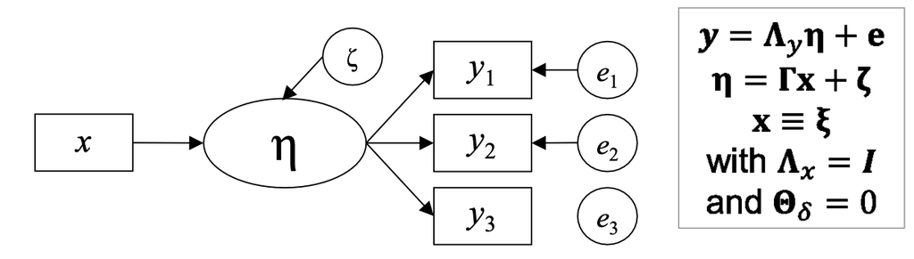

X can be categorical and continuous

- X dummy coded: examine group differences in the latent mean of $\eta$
- X can represent orthogonal analysis-of-variance design vectors to integrate experimental notions in SEM

Muthén (1989) has used MIMIC to analyze population heterogeneity of parameters in latent variable models

Based on this work, MIMIC can be used to identify noninvariant indicator intercepts Kim, Yoon, and Lee (2012)

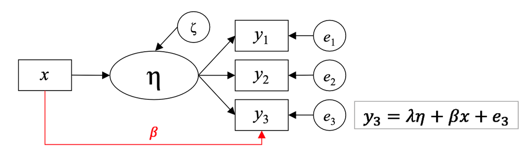

## MIMIC - Universalism

**Does the latent mean of universalism differ by educational level in DE?**

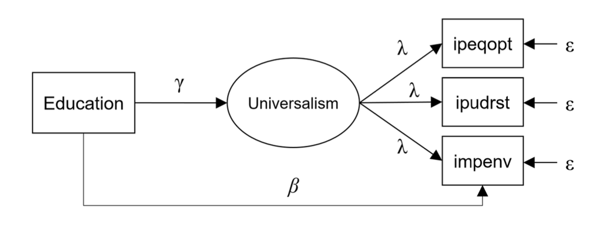

```r
ESS07_countries <- ESS07 %>%
  split(as.factor(.$country))
```

```r
mimic1_countries <- ESS07_countries %>%
  map(~ sem(
    model = "
      uni =~ ipeqopt + ipudrst + impenv
      uni ~ edu
    ",
    data = .,
    estimator = "MLR",
    # optional if there are missing values
    missing = "fiml.x"
    ))
```

```r
mimic1_countries %>%
  map(~ summary(
    object = .,
    fit.measures = T,
    standardized = T
    # rsquare = T
  ))
```

```
$CZ
lavaan 0.6.14 ended normally after 32 iterations

  Estimator                                         ML
  Optimization method                           NLMINB
  Number of model parameters                        10

  Number of observations                          1393
  Number of missing patterns                         1

Model Test User Model:
                                              Standard      Scaled
  Test Statistic                                 0.065       0.066
  Degrees of freedom                                 2           2
  P-value (Chi-square)                           0.968       0.967
  Scaling correction factor                                  0.980
    Yuan-Bentler correction (Mplus variant)

Model Test Baseline Model:

  Test statistic                               413.397     332.120
  Degrees of freedom                                 6           6
  P-value                                        0.000       0.000
  Scaling correction factor                                  1.245

User Model versus Baseline Model:

  Comparative Fit Index (CFI)                    1.000       1.000
  Tucker-Lewis Index (TLI)                       1.014       1.018

  Robust Comparative Fit Index (CFI)                         1.000
  Robust Tucker-Lewis Index (TLI)                            1.014

Loglikelihood and Information Criteria:

  Loglikelihood user model (H0)              -5995.554   -5995.554
  Scaling correction factor                                  1.202
      for the MLR correction
  Loglikelihood unrestricted model (H1)      -5995.521   -5995.521
  Scaling correction factor                                  1.165
```

[output cut: 234 more lines]

```
    edu               0.270    0.048    5.608    0.000    0.458    0.205

Intercepts:
                   Estimate  Std.Err  z-value  P(>|z|)   Std.lv  Std.all
   .ipeqopt           4.919    0.029  167.269    0.000    4.919    4.656
   .ipudrst           4.630    0.029  160.181    0.000    4.630    4.387
   .impenv            4.796    0.028  169.866    0.000    4.796    4.430
   .uni               0.000                               0.000    0.000

Variances:
                   Estimate  Std.Err  z-value  P(>|z|)   Std.lv  Std.all
   .ipeqopt           0.769    0.056   13.812    0.000    0.769    0.689
   .ipudrst           0.650    0.062   10.450    0.000    0.650    0.584
   .impenv            0.994    0.043   23.109    0.000    0.994    0.848
   .uni               0.333    0.049    6.732    0.000    0.958    0.958
```

**Result**

- The mean on the unviersalism latent variable of people with „lower and higher tertiary“ education is 0.171 in CZ, 0.125 in DE and 0.270 in GB units higher than the mean of people „below tertiary“ education.

**Is the intercept of the indicator impenv invariant across educational levels?**

```r
mimic2_countries <- ESS07_countries %>%
  map(~ sem(
    model = "
      uni =~ ipeqopt + ipudrst + impenv
      uni ~ edu
      impenv ~ edu
    ",
    data = .,
    estimator = "MLR",
    # optional if there are missing values
    missing = "fiml.x"
    ))
```

```r
mimic2_countries %>%
  map(~ summary(
    object = .,
    fit.measures = T,
    standardized = T
    # rsquare = T
  ))
```

```
$CZ
lavaan 0.6.14 ended normally after 37 iterations

  Estimator                                         ML
  Optimization method                           NLMINB
  Number of model parameters                        11

  Number of observations                          1393
  Number of missing patterns                         1

Model Test User Model:
                                              Standard      Scaled
  Test Statistic                                 0.001       0.001
  Degrees of freedom                                 1           1
  P-value (Chi-square)                           0.977       0.974
  Scaling correction factor                                  0.829
    Yuan-Bentler correction (Mplus variant)

Model Test Baseline Model:

  Test statistic                               413.397     332.120
  Degrees of freedom                                 6           6
  P-value                                        0.000       0.000
  Scaling correction factor                                  1.245

User Model versus Baseline Model:

  Comparative Fit Index (CFI)                    1.000       1.000
  Tucker-Lewis Index (TLI)                       1.015       1.018

  Robust Comparative Fit Index (CFI)                         1.000
  Robust Tucker-Lewis Index (TLI)                            1.012

Loglikelihood and Information Criteria:

  Loglikelihood user model (H0)              -5995.522   -5995.522
  Scaling correction factor                                  1.195
      for the MLR correction
  Loglikelihood unrestricted model (H1)      -5995.521   -5995.521
  Scaling correction factor                                  1.165
```

[output cut: 240 more lines]

```
    edu              -0.134    0.060   -2.255    0.024   -0.134   -0.055

Intercepts:
                   Estimate  Std.Err  z-value  P(>|z|)   Std.lv  Std.all
   .ipeqopt           4.912    0.030  165.878    0.000    4.912    4.649
   .ipudrst           4.623    0.029  160.240    0.000    4.623    4.381
   .impenv            4.824    0.031  156.678    0.000    4.824    4.456
   .uni               0.000                               0.000    0.000

Variances:
                   Estimate  Std.Err  z-value  P(>|z|)   Std.lv  Std.all
   .ipeqopt           0.764    0.053   14.503    0.000    0.764    0.684
   .ipudrst           0.668    0.057   11.627    0.000    0.668    0.600
   .impenv            0.980    0.044   22.247    0.000    0.980    0.836
   .uni               0.334    0.046    7.219    0.000    0.950    0.950
```

**Result**

- There is no indication of an intercept difference on the „impenv“ indicator between educational groups in CZ and DE.
- In GB, on the other hand, respondents with “lower and higher tertiary” achieve -0.134 units lower than the mean of people “below tertiary” education.

# References

Flake, Jessica K., and D. Betsy McCoach. 2018. “An Investigation of the Alignment Method With Polytomous Indicators Under Conditions of Partial Measurement Invariance.” *Structural Equation Modeling: A Multidisciplinary Journal* 25 (1): 56–70. https://doi.org/10.1080/10705511.2017.1374187.

Kim, Eun Sook, Myeongsun Yoon, and Taehun Lee. 2012. “Testing Measurement Invariance Using MIMIC: Likelihood Ratio Test With a Critical Value Adjustment.” *Educational and Psychological Measurement* 72 (3): 469–92. https://doi.org/10.1177/0013164411427395.

Munck, Ingrid, Carolyn Barber, and Judith Torney-Purta. 2018. “Measurement Invariance in Comparing Attitudes Toward Immigrants Among Youth Across Europe in 1999 and 2009: The Alignment Method Applied to IEA CIVED and ICCS.” *Sociological Methods & Research* 47 (4): 687–728. https://doi.org/10.1177/0049124117729691.

MuthÃ©n, Bengt, and Tihomir Asparouhov. 2014. “IRT Studies of Many Groups: The Alignment Method.” *Frontiers in Psychology* 5 (September). https://doi.org/10.3389/fpsyg.2014.00978.

Muthén, Bengt O. 1989. “Latent Variable Modeling in Heterogeneous Populations.” *Psychometrika* 54 (4): 557–85. https://doi.org/10.1007/BF02296397.

Robitzsch, Alexander. 2020. “Lp Loss Functions in Invariance Alignment and Haberman Linking with Few or Many Groups.” *Stats* 3 (3): 246–83. https://doi.org/10.3390/stats3030019.

Zercher, Florian, Peter Schmidt, Jan Cieciuch, and Eldad Davidov. 2015. “The Comparability of the Universalism Value over Time and Across Countries in the European Social Survey: Exact Vs. Approximate Measurement Invariance.” *Frontiers in Psychology* 6 (June). https://doi.org/10.3389/fpsyg.2015.00733.